# modelAnalysis

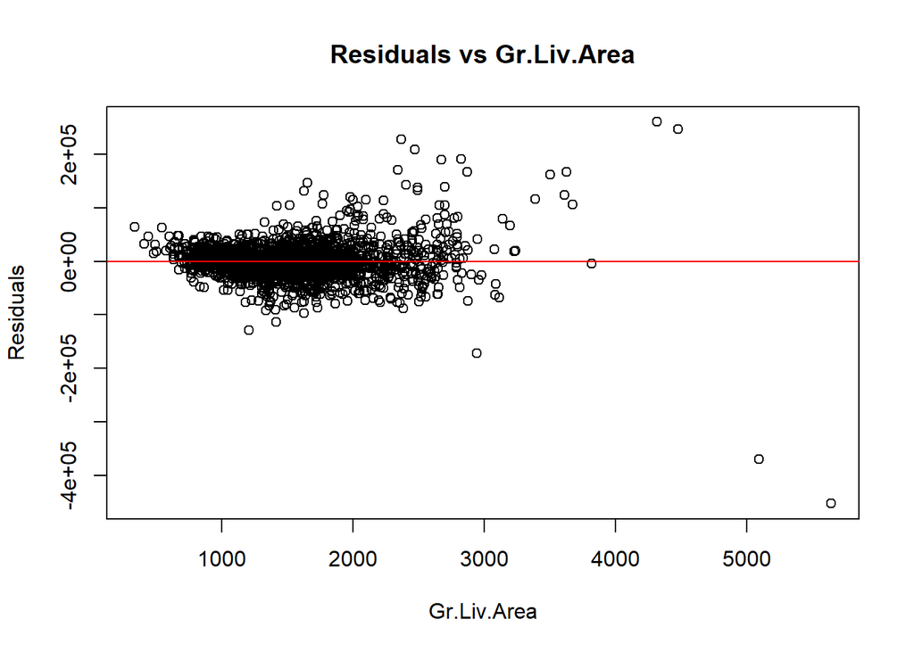

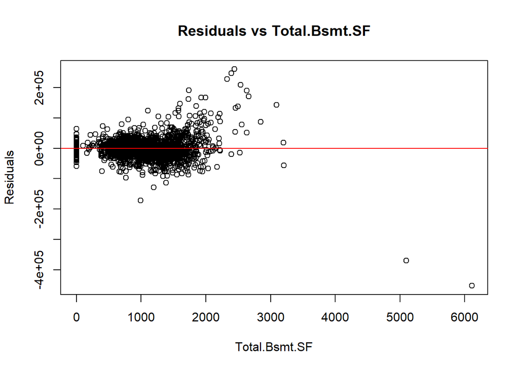

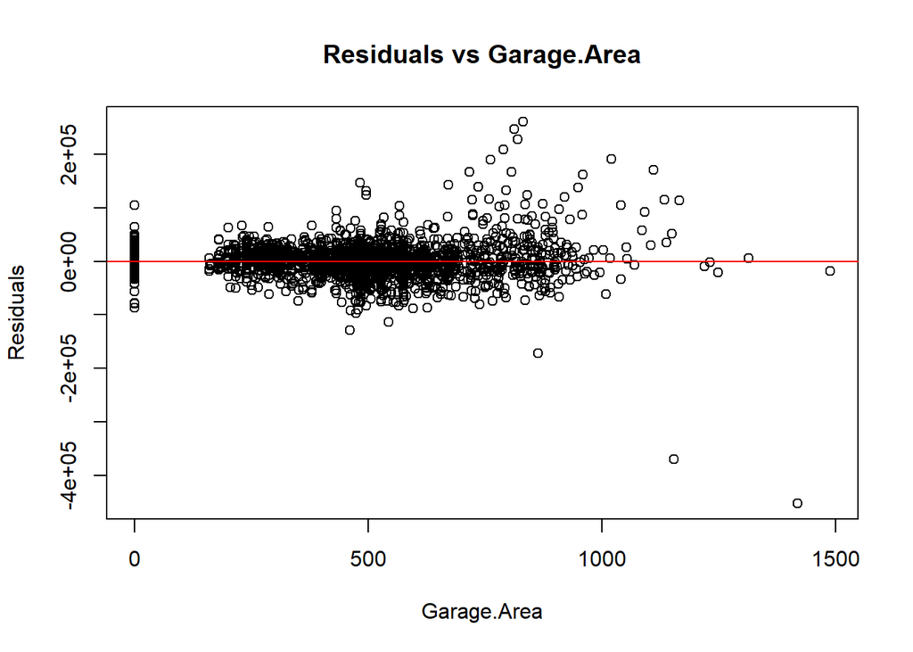

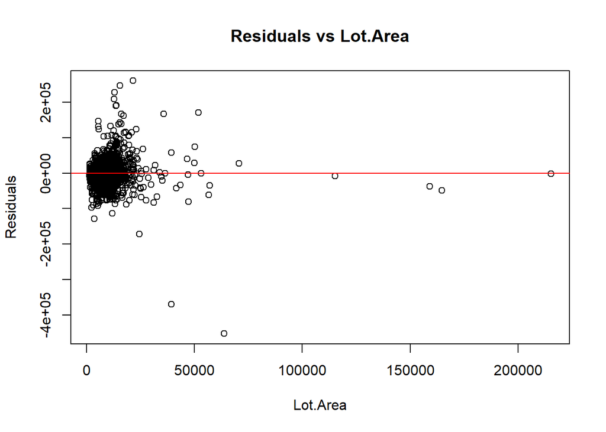

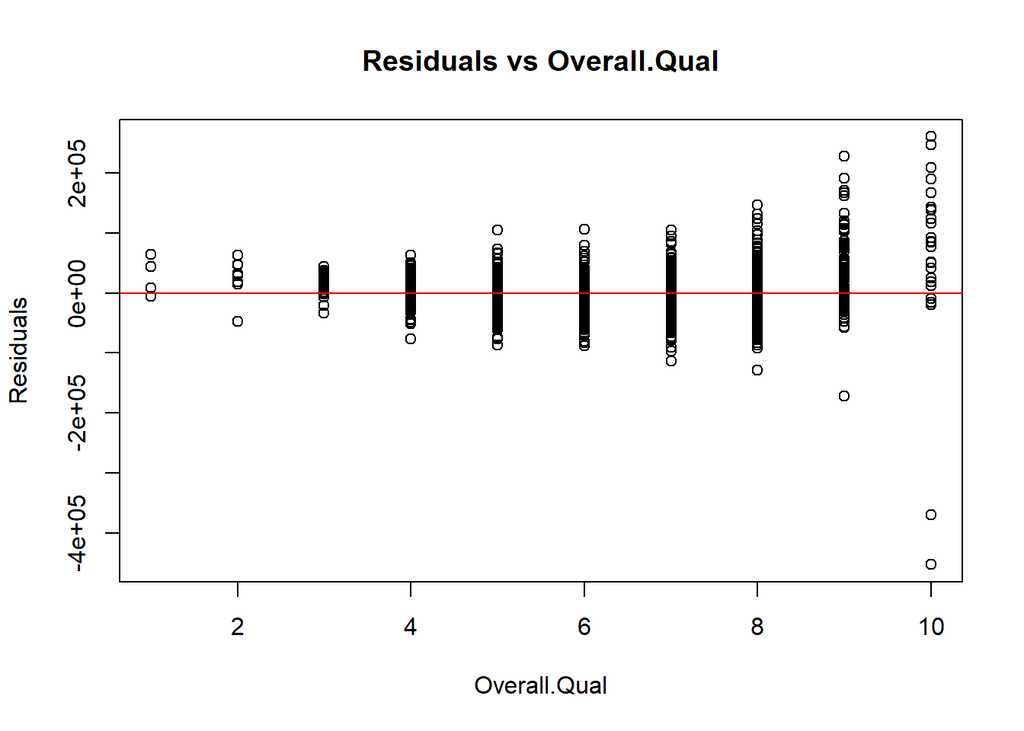

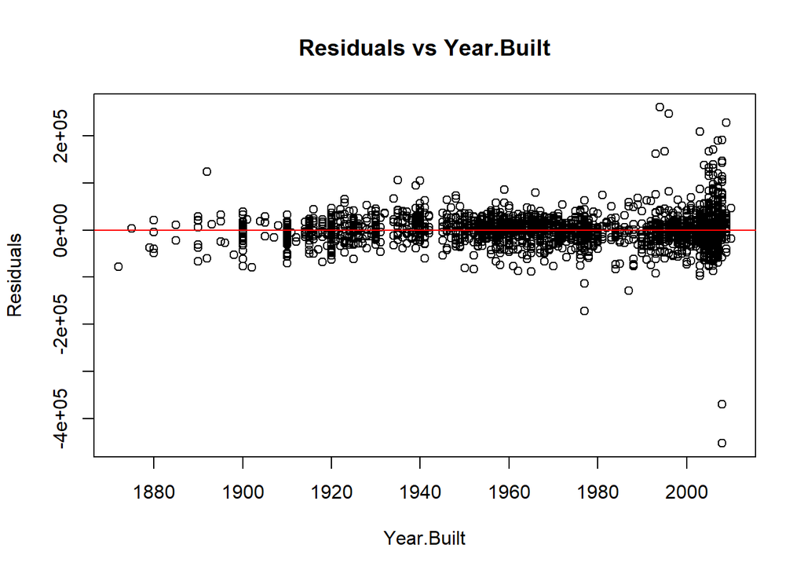

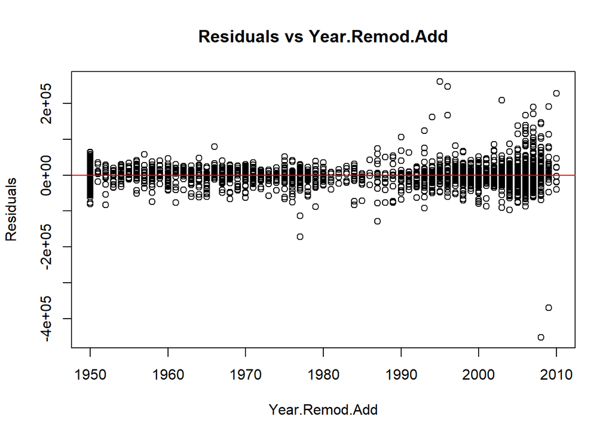

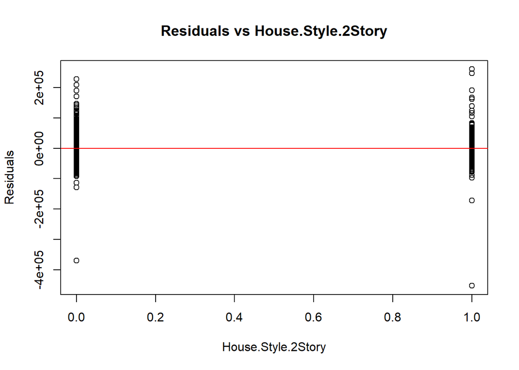

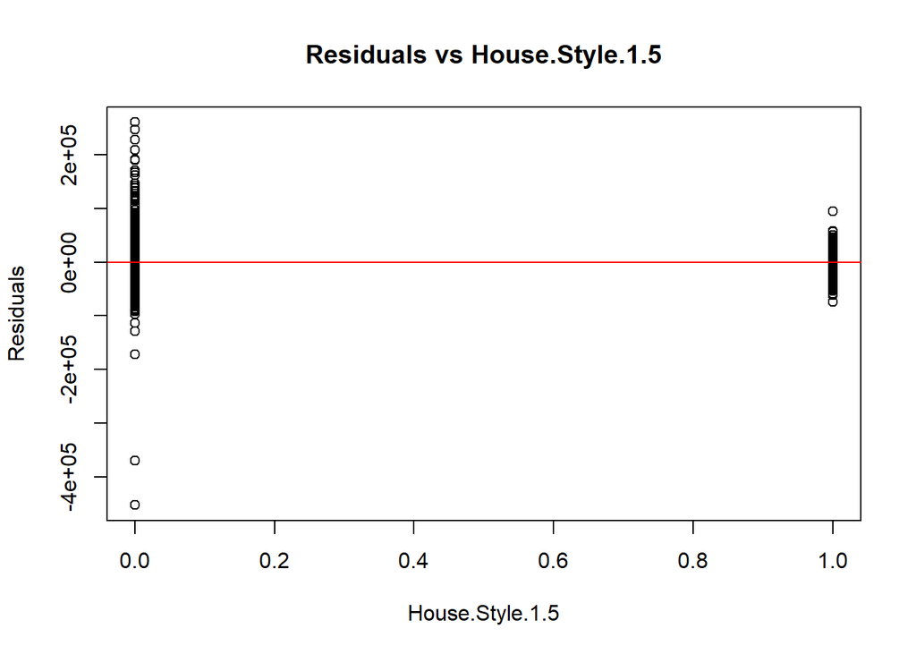

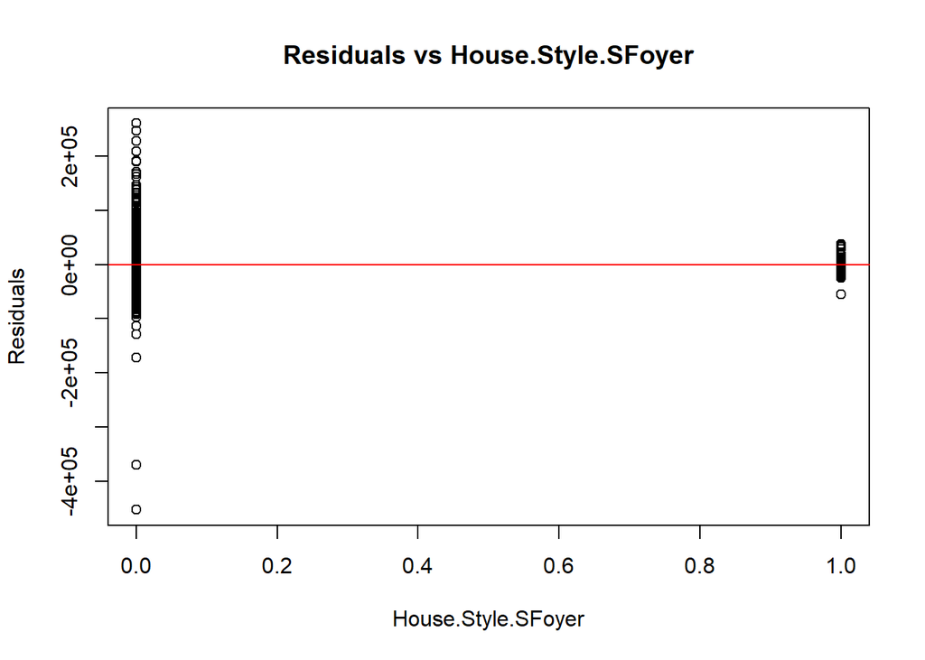

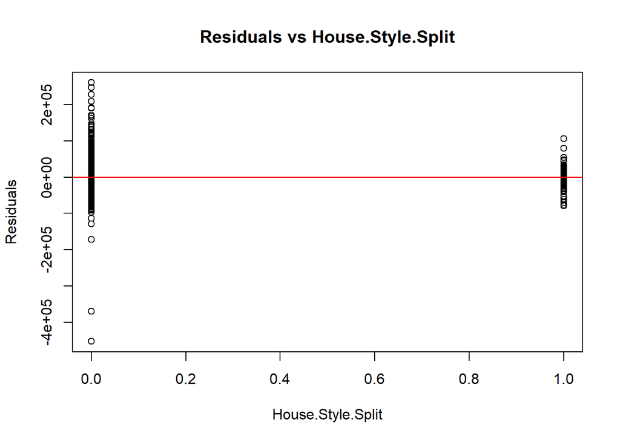

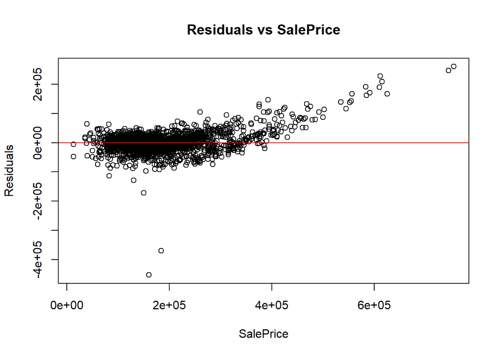

[3 more figures not shown]

```r
for (var in names(train2)){
  plot(train2[[var]], resid(modelAlt), main = paste("Residuals vs", var),
       xlab = var, ylab = "Residuals")
  abline(h = 0, col = "red")
}
```

Variables that seems to show heteroskedasticity are: * Gr.Liv.Area * Total.Bsmt.SF * Garage.Area * Lot.Area * Overall.Qual * Year.Built * Year.Remod.Add

We can test for heteroskedasticity using the **white test**

```r
library(skedastic)
```

```r
white(modelAlt, interactions = TRUE)
```

```
## # A tibble: 1 × 5
##   statistic p.value parameter method       alternative
##       <dbl>   <dbl>     <dbl> <chr>        <chr>
## 1     1949.       0       119 White's Test greater
```

```r
white(modelFull, interactions = TRUE)
```

```
## # A tibble: 1 × 5
##   statistic  p.value parameter method       alternative
##       <dbl>    <dbl>     <dbl> <chr>        <chr>
## 1     2047. 1.07e-90       902 White's Test greater
```

Since there is heteroskedasticity, I will recalculate the standard errors of my coefficients to obtain robust standard errors since the actual standard errors right now are too optimistic for a heteroskedsticity case scenario

```r
library(sandwich)
library(lmtest)
coeftest(modelAlt, vcov = vcovHC(modelAlt, type = "HC1"))
```

```
##
## t test of coefficients:
##
##                                       Estimate  Std. Error t value  Pr(>|t|)
## (Intercept)                        -8.1501e+05  1.1135e+05 -7.3193 3.414e-13
## Gr.Liv.Area                         5.3289e+01  4.5525e+00 11.7053 < 2.2e-16
## Total.Bsmt.SF                       1.7355e+01  8.9127e+00  1.9472  0.051631
## Garage.Area                         3.2278e+01  4.3744e+00  7.3789 2.210e-13
## Lot.Area                            6.4101e-01  1.3021e-01  4.9228 9.127e-07
## Overall.Qual                        1.7096e+04  1.1687e+03 14.6276 < 2.2e-16
## Year.Built                          1.4717e+02  4.6086e+01  3.1933  0.001425
## Year.Remod.Add                      2.4084e+02  3.7081e+01  6.4951 1.012e-10
## House.Style.2Story                 -1.1933e+04  3.7691e+03 -3.1662  0.001565
## House.Style.1.5                    -8.4943e+03  2.6174e+03 -3.2453  0.001190
## House.Style.SFoyer                  7.3213e+03  2.4960e+03  2.9332  0.003387
## House.Style.Split                  -5.9668e+03  3.2650e+03 -1.8275  0.067747
## Neighborhood_Price_Range.High       9.9097e+03  2.3064e+03  4.2967 1.805e-05
## Neighborhood_Price_Range.Very_High  6.3757e+04  7.2739e+03  8.7651 < 2.2e-16
## Neighborhood_Price_Range.Low       -4.3492e+03  3.8450e+03 -1.1311  0.258123
##
## (Intercept)                        ***
## Gr.Liv.Area                        ***
## Total.Bsmt.SF                      .
## Garage.Area                        ***
## Lot.Area                           ***
## Overall.Qual                       ***
## Year.Built                         **
## Year.Remod.Add                     ***
## House.Style.2Story                 **
## House.Style.1.5                    **
## House.Style.SFoyer                 **
## House.Style.Split                  .
## Neighborhood_Price_Range.High      ***
## Neighborhood_Price_Range.Very_High ***
## Neighborhood_Price_Range.Low
## ---
## Signif. codes:  0 '***' 0.001 '**' 0.01 '*' 0.05 '.' 0.1 ' ' 1
```

```r
coeftest(modelFull, vcov = vcovHC(modelFull, type = "HC1"))
```

```
##
## t test of coefficients:
##
##                         Estimate  Std. Error t value  Pr(>|t|)
## (Intercept)          -1.0940e+06  1.5443e+05 -7.0838 1.856e-12 ***
## Gr.Liv.Area           5.4043e+01  4.8656e+00 11.1071 < 2.2e-16 ***
## Total.Bsmt.SF         1.6148e+01  9.0694e+00  1.7805  0.075129 .
## Garage.Area           3.2982e+01  4.4843e+00  7.3551 2.639e-13 ***
## Lot.Area              6.0236e-01  1.4367e-01  4.1927 2.860e-05 ***
## Overall.Qual          1.6707e+04  1.1783e+03 14.1792 < 2.2e-16 ***
## Year.Built            2.5692e+02  6.2790e+01  4.0918 4.428e-05 ***
## Year.Remod.Add        2.7510e+02  3.7007e+01  7.4338 1.480e-13 ***
## Neighborhood.Gilbert -4.5139e+03  3.7975e+03 -1.1887  0.234700
## Neighborhood.StoneBr  6.9062e+04  1.3384e+04  5.1599 2.682e-07 ***
## Neighborhood.NWAmes  -7.2886e+03  4.0544e+03 -1.7977  0.072356 .
## Neighborhood.Somerst  8.6576e+03  4.9250e+03  1.7579  0.078902 .
## Neighborhood.BrDale  -1.4965e+04  4.7546e+03 -3.1475  0.001668 **
## Neighborhood.NPkVill -1.3271e+04  2.8914e+03 -4.5899 4.673e-06 ***
## Neighborhood.NridgHt  5.4150e+04  9.3691e+03  5.7796 8.504e-09 ***
## Neighborhood.Blmngtn -1.1603e+04  6.6872e+03 -1.7351  0.082852 .
## Neighborhood.NoRidge  5.4150e+04  1.1611e+04  4.6636 3.285e-06 ***
## Neighborhood.SawyerW -7.8228e+03  3.4579e+03 -2.2623  0.023773 *
## Neighborhood.Sawyer  -3.1739e+02  2.1714e+03 -0.1462  0.883798
## Neighborhood.Greens  -1.4080e+03  6.0022e+03 -0.2346  0.814561
## Neighborhood.BrkSide  8.8313e+03  4.6073e+03  1.9168  0.055386 .
## Neighborhood.OldTown -5.1765e+03  3.9808e+03 -1.3004  0.193604
## Neighborhood.IDOTRR  -2.0338e+03  5.0142e+03 -0.4056  0.685070
## Neighborhood.ClearCr  1.2351e+04  6.8342e+03  1.8072  0.070867 .
## Neighborhood.SWISU   -5.1585e+03  4.8896e+03 -1.0550  0.291540
## Neighborhood.Edwards -4.5792e+03  5.4168e+03 -0.8454  0.397988
## Neighborhood.CollgCr -6.7805e+02  3.8723e+03 -0.1751  0.861014
## Neighborhood.Crawfor  2.8417e+04  4.5523e+03  6.2424 5.116e-10 ***
## Neighborhood.Blueste -1.6386e+04  5.3126e+03 -3.0843  0.002065 **
## Neighborhood.Mitchel -3.1743e+03  3.5998e+03 -0.8818  0.377974
## Neighborhood.Timber   1.3844e+04  7.7050e+03  1.7967  0.072517 .
## Neighborhood.MeadowV -5.5215e+03  4.4736e+03 -1.2342  0.217243
## Neighborhood.Veenker  1.1550e+04  1.2588e+04  0.9175  0.358975
## Neighborhood.GrnHill  1.2327e+05  5.3293e+03 23.1300 < 2.2e-16 ***
## Neighborhood.Landmrk -1.9473e+04  3.4360e+03 -5.6673 1.632e-08 ***
## House.Style.2Story   -1.0077e+04  4.1428e+03 -2.4323  0.015078 *
## House.Style.1.5Fin   -1.0812e+04  2.7410e+03 -3.9446 8.231e-05 ***
## House.Style.SFoyer    6.5770e+03  2.5928e+03  2.5367  0.011257 *
## House.Style.SLvl     -2.1239e+03  3.4320e+03 -0.6188  0.536080
## House.Style.2.5Unf   -2.4644e+04  9.0381e+03 -2.7266  0.006447 **
## House.Style.1.5Unf   -3.9580e+03  5.4330e+03 -0.7285  0.466373
## House.Style.2.5Fin   -7.2443e+03  3.1565e+04 -0.2295  0.818497
## ---
## Signif. codes:  0 '***' 0.001 '**' 0.01 '*' 0.05 '.' 0.1 ' ' 1
```

# Autocorrelation

```r
bgtest(modelAlt)
```

```
##
##  Breusch-Godfrey test for serial correlation of order up to 1
##
## data:  modelAlt
## LM test = 51.608, df = 1, p-value = 6.776e-13
```

```r
bgtest(modelFull)
```

```
##
##  Breusch-Godfrey test for serial correlation of order up to 1
##
## data:  modelFull
## LM test = 33.983, df = 1, p-value = 5.56e-09
```

Autocorellation is present in both models

```r
# Update robust test to handle both Heteroscedasticity AND Autocorrelation
robustAlt <- vcovHAC(modelAlt)
coeftest(modelAlt, vcov = robustAlt)
```

```
##
## t test of coefficients:
##
##                                       Estimate  Std. Error t value  Pr(>|t|)
## (Intercept)                        -8.1501e+05  1.1409e+05 -7.1439 1.208e-12
## Gr.Liv.Area                         5.3289e+01  4.5947e+00 11.5979 < 2.2e-16
## Total.Bsmt.SF                       1.7355e+01  8.9289e+00  1.9437  0.052056
## Garage.Area                         3.2278e+01  4.4082e+00  7.3223 3.341e-13
## Lot.Area                            6.4101e-01  1.3045e-01  4.9137 9.557e-07
## Overall.Qual                        1.7096e+04  1.1790e+03 14.5007 < 2.2e-16
## Year.Built                          1.4717e+02  4.7083e+01  3.1257  0.001795
## Year.Remod.Add                      2.4084e+02  3.7412e+01  6.4376 1.469e-10
## House.Style.2Story                 -1.1933e+04  3.7786e+03 -3.1582  0.001608
## House.Style.1.5                    -8.4943e+03  2.6099e+03 -3.2546  0.001152
## House.Style.SFoyer                  7.3213e+03  2.5790e+03  2.8388  0.004568
## House.Style.Split                  -5.9668e+03  3.3518e+03 -1.7802  0.075178
## Neighborhood_Price_Range.High       9.9097e+03  2.4396e+03  4.0620 5.025e-05
## Neighborhood_Price_Range.Very_High  6.3757e+04  7.5974e+03  8.3919 < 2.2e-16
## Neighborhood_Price_Range.Low       -4.3492e+03  3.8996e+03 -1.1153  0.264847
##
## (Intercept)                        ***
## Gr.Liv.Area                        ***
## Total.Bsmt.SF                      .
## Garage.Area                        ***
## Lot.Area                           ***
## Overall.Qual                       ***
## Year.Built                         **
## Year.Remod.Add                     ***
## House.Style.2Story                 **
## House.Style.1.5                    **
## House.Style.SFoyer                 **
## House.Style.Split                  .
## Neighborhood_Price_Range.High      ***
## Neighborhood_Price_Range.Very_High ***
## Neighborhood_Price_Range.Low
## ---
## Signif. codes:  0 '***' 0.001 '**' 0.01 '*' 0.05 '.' 0.1 ' ' 1
```

No significant difference from previously calculated robust standard errors for coefficients

```r
# Update  robust test to handle both Heteroscedasticity AND Autocorrelation
robustFull <- vcovHAC(modelFull)
coeftest(modelFull, vcov = robustFull)
```

```
##
## t test of coefficients:
##
##                         Estimate  Std. Error t value  Pr(>|t|)
## (Intercept)          -1.0940e+06  1.6212e+05 -6.7477 1.894e-11 ***
## Gr.Liv.Area           5.4043e+01  4.9328e+00 10.9560 < 2.2e-16 ***
## Total.Bsmt.SF         1.6148e+01  9.0276e+00  1.7887 0.0737894 .
## Garage.Area           3.2982e+01  4.5005e+00  7.3286 3.204e-13 ***
## Lot.Area              6.0236e-01  1.4431e-01  4.1740 3.104e-05 ***
## Overall.Qual          1.6707e+04  1.1863e+03 14.0841 < 2.2e-16 ***
## Year.Built            2.5692e+02  6.5951e+01  3.8957 0.0001007 ***
## Year.Remod.Add        2.7510e+02  3.7260e+01  7.3835 2.144e-13 ***
## Neighborhood.Gilbert -4.5139e+03  4.1473e+03 -1.0884 0.2765322
## Neighborhood.StoneBr  6.9062e+04  1.4570e+04  4.7400 2.268e-06 ***
## Neighborhood.NWAmes  -7.2886e+03  4.1821e+03 -1.7428 0.0815002 .
## Neighborhood.Somerst  8.6576e+03  5.2494e+03  1.6492 0.0992331 .
## Neighborhood.BrDale  -1.4965e+04  4.6689e+03 -3.2053 0.0013677 **
## Neighborhood.NPkVill -1.3271e+04  2.5619e+03 -5.1801 2.410e-07 ***
## Neighborhood.NridgHt  5.4150e+04  9.9321e+03  5.4520 5.514e-08 ***
## Neighborhood.Blmngtn -1.1603e+04  7.5608e+03 -1.5347 0.1250073
## Neighborhood.NoRidge  5.4150e+04  1.1564e+04  4.6824 3.000e-06 ***
## Neighborhood.SawyerW -7.8228e+03  3.7180e+03 -2.1040 0.0354829 *
## Neighborhood.Sawyer  -3.1739e+02  2.1955e+03 -0.1446 0.8850662
## Neighborhood.Greens  -1.4080e+03  6.0810e+03 -0.2315 0.8169218
## Neighborhood.BrkSide  8.8313e+03  4.6489e+03  1.8997 0.0576034 .
## Neighborhood.OldTown -5.1765e+03  4.1014e+03 -1.2621 0.2070283
## Neighborhood.IDOTRR  -2.0338e+03  5.0620e+03 -0.4018 0.6878898
## Neighborhood.ClearCr  1.2351e+04  6.9974e+03  1.7650 0.0776912 .
## Neighborhood.SWISU   -5.1585e+03  4.9149e+03 -1.0496 0.2940307
## Neighborhood.Edwards -4.5792e+03  5.6058e+03 -0.8169 0.4140913
## Neighborhood.CollgCr -6.7805e+02  4.0517e+03 -0.1674 0.8671087
## Neighborhood.Crawfor  2.8417e+04  5.0681e+03  5.6071 2.304e-08 ***
## Neighborhood.Blueste -1.6386e+04  5.2930e+03 -3.0957 0.0019872 **
## Neighborhood.Mitchel -3.1743e+03  3.7097e+03 -0.8557 0.3922713
## Neighborhood.Timber   1.3844e+04  8.0808e+03  1.7131 0.0868228 .
## Neighborhood.MeadowV -5.5215e+03  4.5280e+03 -1.2194 0.2228135
## Neighborhood.Veenker  1.1550e+04  1.1767e+04  0.9816 0.3264140
## Neighborhood.GrnHill  1.2327e+05  5.4220e+03 22.7345 < 2.2e-16 ***
## Neighborhood.Landmrk -1.9473e+04  3.5874e+03 -5.4282 6.291e-08 ***
## House.Style.2Story   -1.0077e+04  4.1119e+03 -2.4506 0.0143349 *
## House.Style.1.5Fin   -1.0812e+04  2.7093e+03 -3.9908 6.790e-05 ***
## House.Style.SFoyer    6.5770e+03  2.6986e+03  2.4372 0.0148763 *
## House.Style.SLvl     -2.1239e+03  3.4119e+03 -0.6225 0.5336750
## House.Style.2.5Unf   -2.4644e+04  9.1733e+03 -2.6865 0.0072734 **
## House.Style.1.5Unf   -3.9580e+03  5.3813e+03 -0.7355 0.4621005
## House.Style.2.5Fin   -7.2443e+03  3.1692e+04 -0.2286 0.8192094
## ---
## Signif. codes:  0 '***' 0.001 '**' 0.01 '*' 0.05 '.' 0.1 ' ' 1
```

No significant difference from previously calculated robust standard errors for coefficients

# Normality check

The qq plot shows that residuals are not normally distributed, let’s do a test to verify it

```r
shapiro.test(resid(modelAlt))
```

```
##
##  Shapiro-Wilk normality test
##
## data:  resid(modelAlt)
## W = 0.82938, p-value < 2.2e-16
```

```r
shapiro.test(resid(modelFull))
```

```
##
##  Shapiro-Wilk normality test
##
## data:  resid(modelFull)
## W = 0.8129, p-value < 2.2e-16
```

To solve this issue we can try a log transformation of the target variable ## Log transform

**modelAlt**

```r
train2$Log_SalePrice <- log(train2$SalePrice)
modelLogAlt <- lm(Log_SalePrice ~ . - SalePrice , train2)
```

**modelFull**

```r
train$Log_SalePrice <- log(train$SalePrice)
modelLogFull <- lm(Log_SalePrice ~ . - SalePrice , train)
```

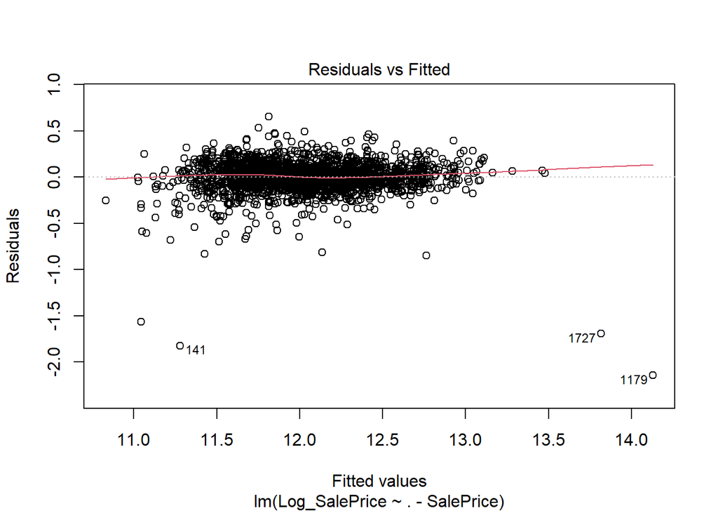

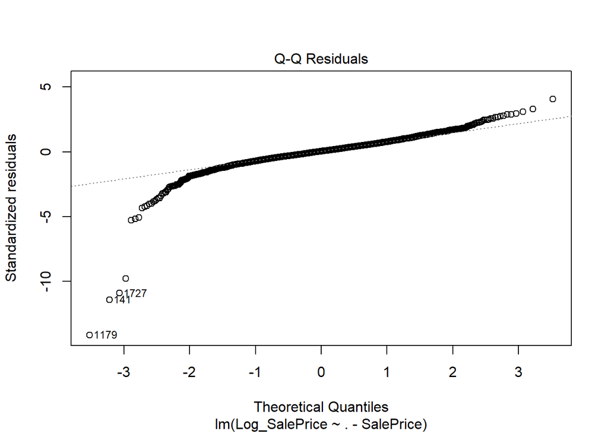

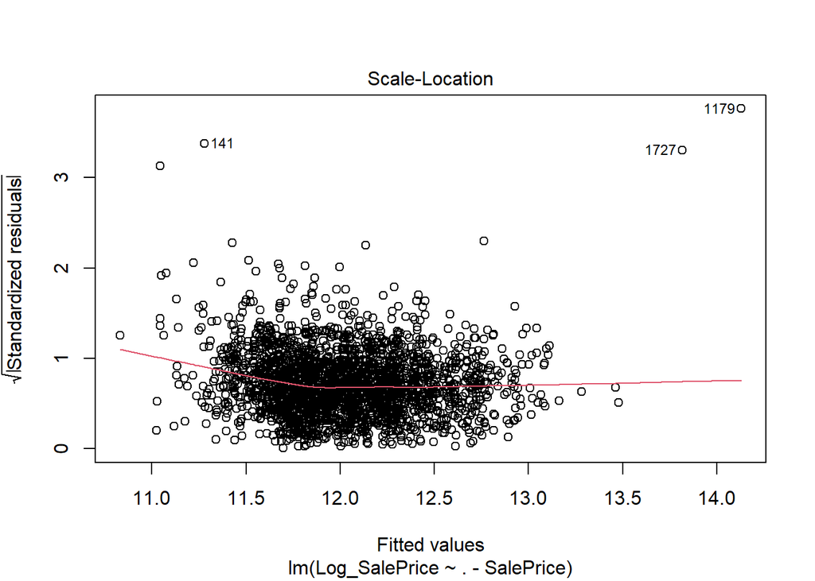

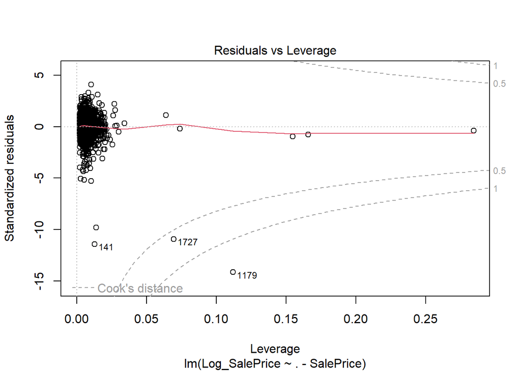

```r
plot(modelLogAlt)
```

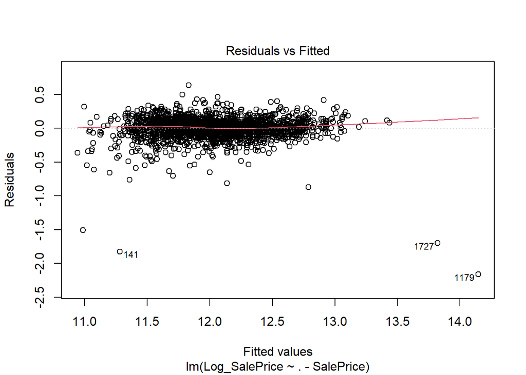

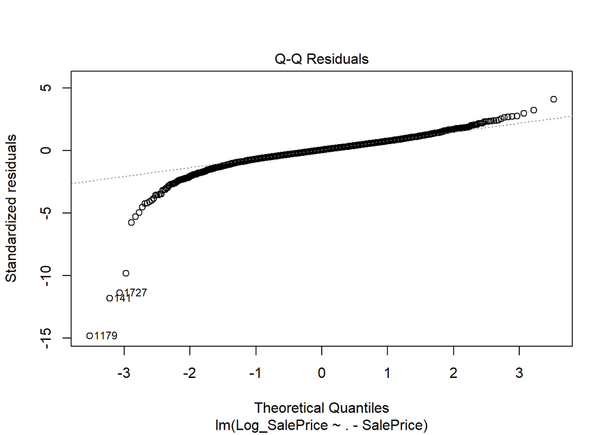

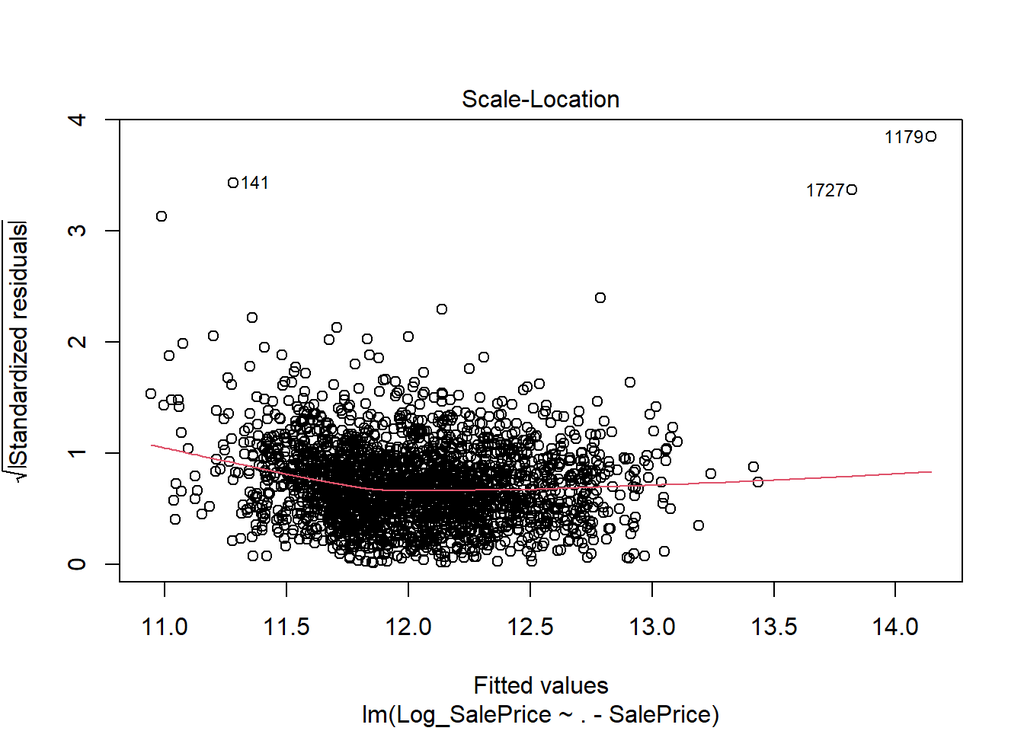

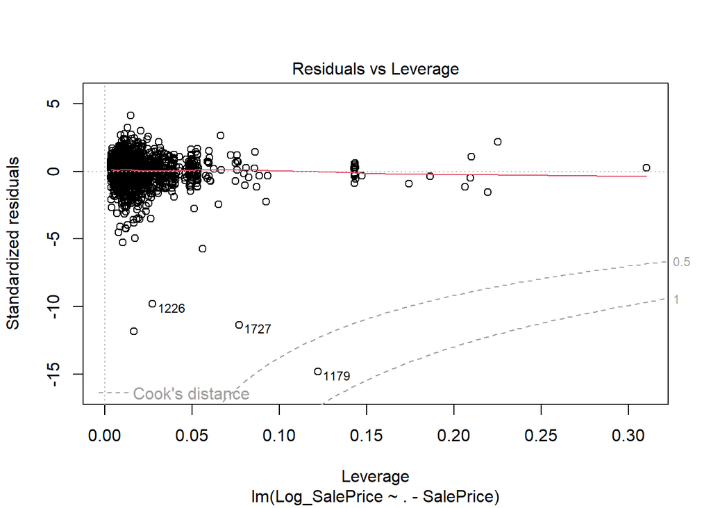

```r
plot(modelLogFull)
```

The qq plot looks better for both models, let’s do again the shapiro test **modelAlt**

```r
shapiro.test(resid(modelLogAlt))
```

```
##
##  Shapiro-Wilk normality test
##
## data:  resid(modelLogAlt)
## W = 0.83943, p-value < 2.2e-16
```

```r
shapiro.test(resid(modelLogFull))
```

```
##
##  Shapiro-Wilk normality test
##
## data:  resid(modelLogFull)
## W = 0.82338, p-value < 2.2e-16
```

Probably do to outliers there are still problems with normality of residuals but the situation is improved compared to previous models without log transformation of the target variable.

Let’s remove the outliers

**modelAlt**

```r
# Find points that have high influence (Cook's) AND high error (Studentized Residual)
cooksAlt    <- cooks.distance(modelLogAlt)
cook_cutoff <- 4/(nrow(train2))
influential_indices <- which(cooksAlt > cook_cutoff & abs(rstudent(modelLogAlt)) > 2)

train2_cleaned<- train2[-influential_indices, ]
print(length(influential_indices))
```

```
## [1] 68
```

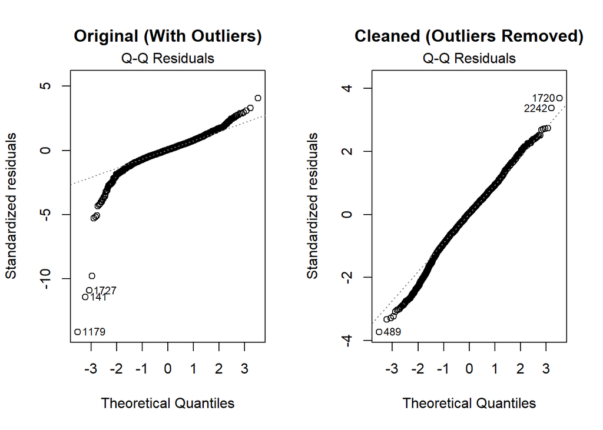

```r
modelLogAlt_cleaned <- lm(Log_SalePrice ~ . - SalePrice , train2_cleaned)
# Compare the Normality visually
par(mfrow=c(1,2))
plot(modelLogAlt, which=2, main="Original (With Outliers)")
plot(modelLogAlt_cleaned, which=2, main="Cleaned (Outliers Removed)")
```

```r
shapiro.test(resid(modelLogAlt_cleaned))
```

```
##
##  Shapiro-Wilk normality test
##
## data:  resid(modelLogAlt_cleaned)
## W = 0.99409, p-value = 6.538e-08
```

**modelFull**

```r
# Find points that have high influence (Cook's) AND high error (Studentized Residual)
cooksFull    <- cooks.distance(modelLogFull)
influential_indices_full <- which(cooksFull > cook_cutoff & abs(rstudent(modelLogFull)) > 2)

traincleaned <- train[-influential_indices_full, ]
print(length(influential_indices_full))
```

```
## [1] 61
```

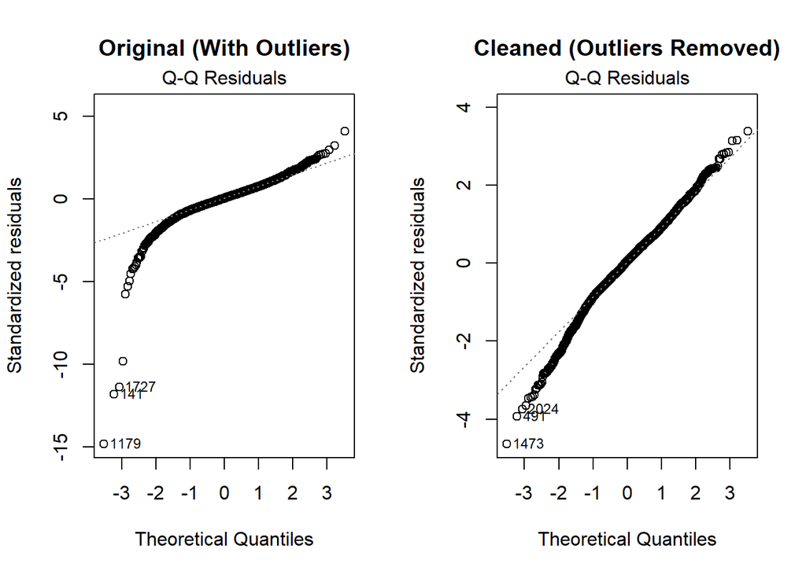

```r
modelLogFull_cleaned <- lm(Log_SalePrice ~ . - SalePrice , traincleaned)
# Compare the Normality visually
par(mfrow=c(1,2))
plot(modelLogFull, which=2, main="Original (With Outliers)")
plot(modelLogFull_cleaned, which=2, main="Cleaned (Outliers Removed)")
```

```r
shapiro.test(resid(modelLogFull_cleaned))
```

```
##
##  Shapiro-Wilk normality test
##
## data:  resid(modelLogFull_cleaned)
## W = 0.98798, p-value = 6.3e-13
```

# Prediction

**modelAlt**

```r
validation2 <- validation %>%
  mutate(Neighborhood_Price_Range = case_when(
    Neighborhood %in% neigh_summary$Neighborhood[1:7] ~ "Low",
    Neighborhood %in% neigh_summary$Neighborhood[8:14] ~ "Medium",
    Neighborhood %in% neigh_summary$Neighborhood[15:24] ~ "High",
    TRUE ~ "Very_High"
  ))

validation2 <- validation2 %>%
  mutate(House.Style = case_when(
    House.Style %in% house_style_summary$House.Style[1:2] ~ "1.5",
    House.Style %in% house_style_summary$House.Style[4] ~ "1Story",
    House.Style %in% house_style_summary$House.Style[3] ~ "SFoyer",
    House.Style %in% house_style_summary$House.Style[5:6] ~ "Split",
    TRUE ~ "2Story"
  ))
validation2$Neighborhood_Price_Range <- factor(validation2$Neighborhood_Price_Range,
                                         levels = c( "Medium", "Low", "High", "Very_High"))
validation2$House.Style <- factor(validation2$House.Style,
                                 levels = c("1Story", "2Story", "1.5",  "SFoyer", "Split"))
validation2 <- select(validation2, -Neighborhood)
validation2 <- as_tibble(predict(dummyVars(~ ., sep = ".", data = validation2, fullRank = TRUE, ), newdata = validation2))
validation2$Log_SalePrice <- log(validation2$SalePrice)
```

```r
predictionsLogAltCleaned<- predict(modelLogAlt_cleaned, newdata = validation2)
predictionsAlt <- exp(predictionsLogAltCleaned)
rmseAltCleaned <- sqrt(mean((validation2$SalePrice - predictionsAlt)^2))
rmseAltCleaned
```

```
## [1] 46788.91
```

with outliers

```r
predictionsLogAlt<- predict(modelLogAlt, newdata = validation2)
predictionsAlt_wOutliers <- exp(predictionsLogAlt)
rmseAlt <- sqrt(mean((validation2$SalePrice - predictionsAlt_wOutliers)^2))
rmseAlt
```

```
## [1] 40406.93
```

**modelFull**

```r
validation$Log_SalePrice <- log(validation$SalePrice)
validation$Neighborhood <- factor(validation$Neighborhood,
                                 levels = levelsOrderNeighborhood)
validation$House.Style <- factor(validation$House.Style,
                                 levels = levelsOrderHouseStyle)
validation_full <- as_tibble(predict(dummyVars(~ ., sep = ".", data = validation
, fullRank = TRUE), newdata = validation))
```

```r
predictionsLogFull<- predict(modelLogFull_cleaned, newdata = validation_full)
predictionsFull <- exp(predictionsLogFull)
rmseFullCleaned <- sqrt(mean((validation$SalePrice - predictionsFull)^2))
rmseFullCleaned
```

```
## [1] 49701.97
```

with outliers

```r
predictionsLogFull_wOutliers<- predict(modelLogFull, newdata = validation_full)
predictionsFull_wOutliers <- exp(predictionsLogFull_wOutliers)
rmseFull <- sqrt(mean((validation$SalePrice - predictionsFull_wOutliers)^2))
rmseFull
```

```
## [1] 41435.25
```

```r
matrix <- as.matrix(train %>% select(-SalePrice, -Log_SalePrice))
response <- train$Log_SalePrice


modelLasso <- cv.glmnet(matrix, response, alpha = 1, nfolds =5)
bestLambda <- modelLasso$lambda.min
validation_dummies <- as_tibble(predict(dummyVars(~ ., sep = ".", data = validation, fullRank = TRUE), newdata = validation))
validation_matrix <- as.matrix(validation_dummies %>% select(-SalePrice, -Log_SalePrice))
predictionsLogLasso<- predict(modelLasso, s = bestLambda, newx = validation_matrix)
predictionsLasso <- exp(predictionsLogLasso)
rmseLasso <- sqrt(mean((validation$SalePrice - predictionsLasso)^2))
rmseLasso
```

```
## [1] 41835.42
```

These rmse are quite higher than the training rmse calculated in the training dataset. The reason could be due to overfitting or the presence of outliers in the validation dataset.

## removing outliers from validation

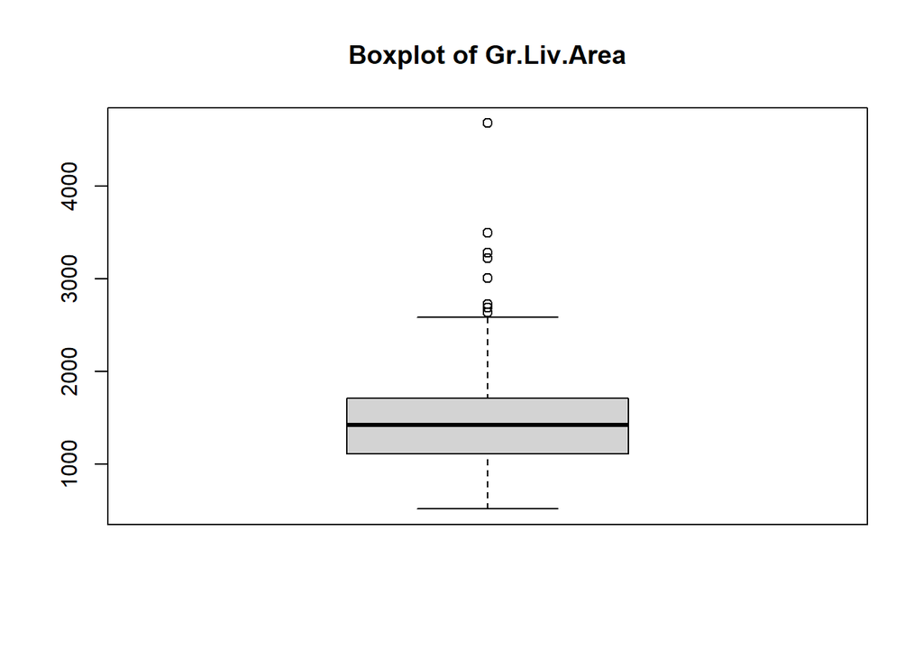

```
## [1] "Removing outliers from Gr.Liv.Area : 9 outliers found"
```

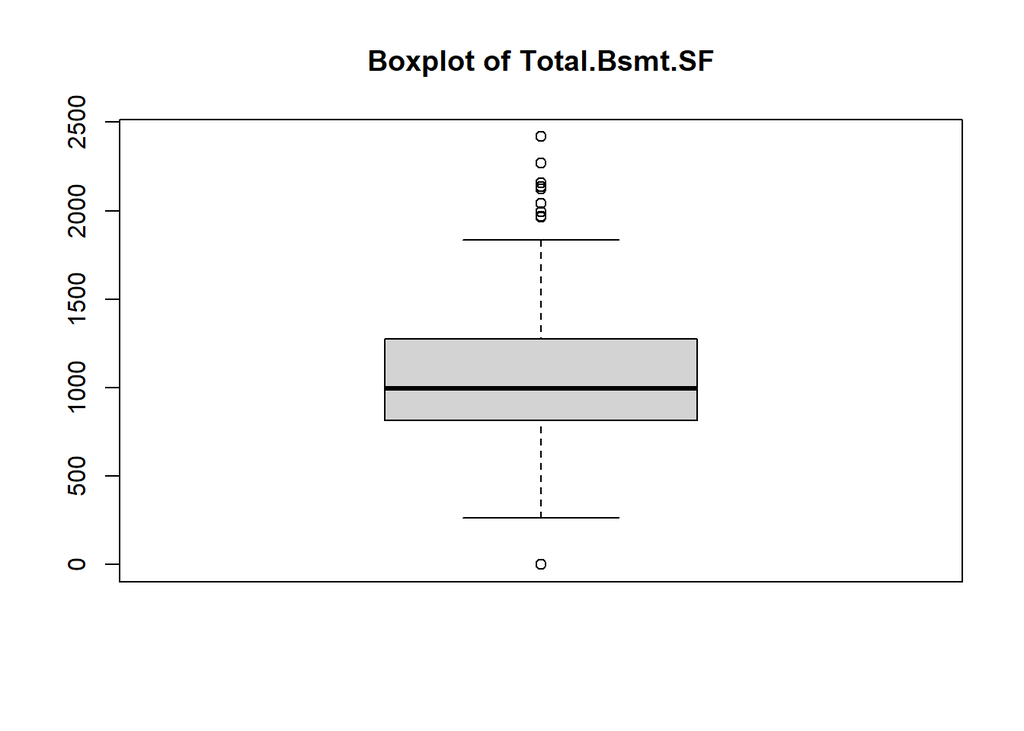

```
## [1] "Removing outliers from Total.Bsmt.SF : 15 outliers found"
```

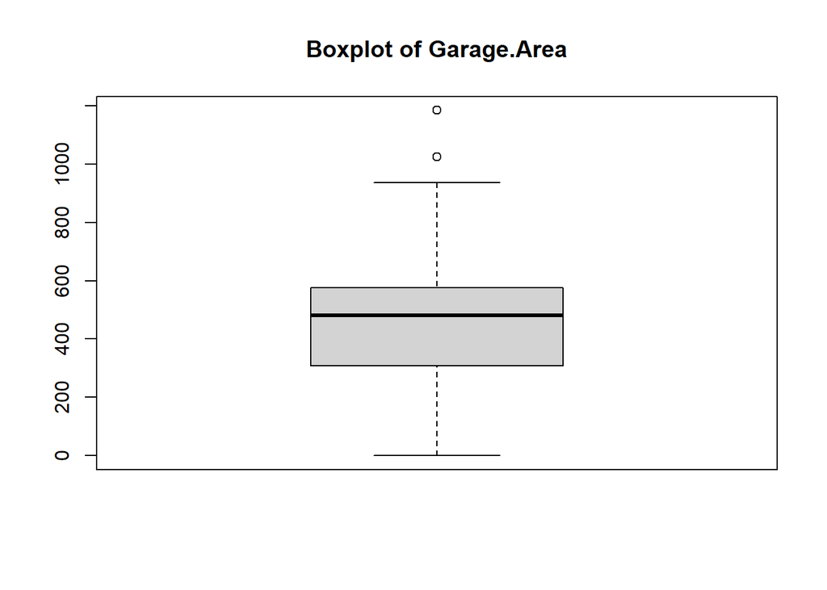

```
## [1] "Removing outliers from Garage.Area : 2 outliers found"
```

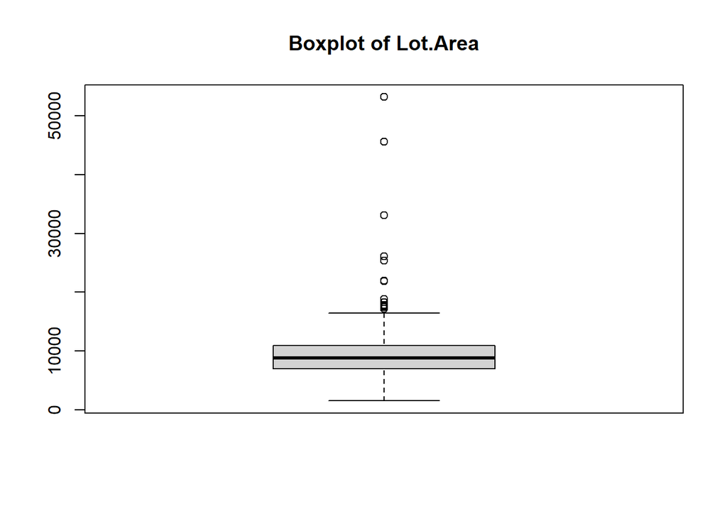

```
## [1] "Removing outliers from Lot.Area : 14 outliers found"
```

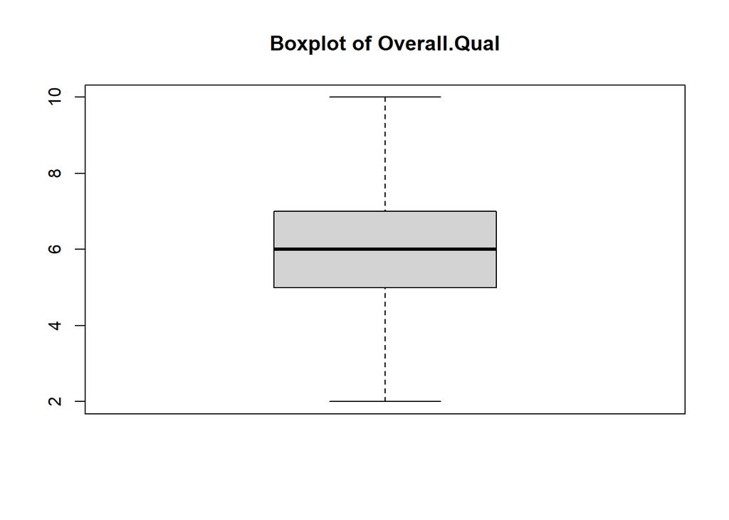

```
## [1] "Removing outliers from Overall.Qual : 0 outliers found"
```

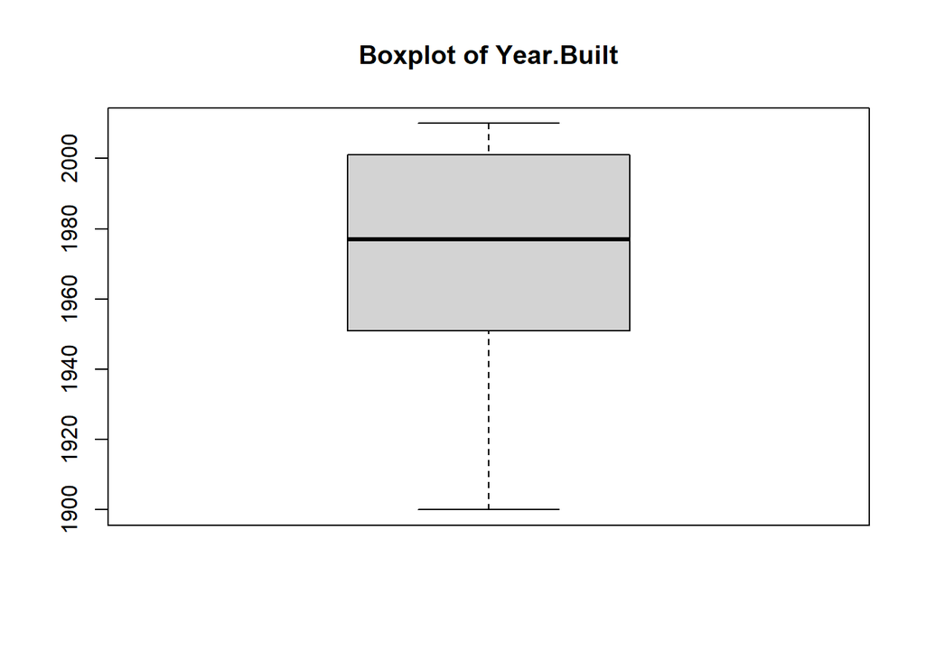

```
## [1] "Removing outliers from Year.Built : 0 outliers found"
```

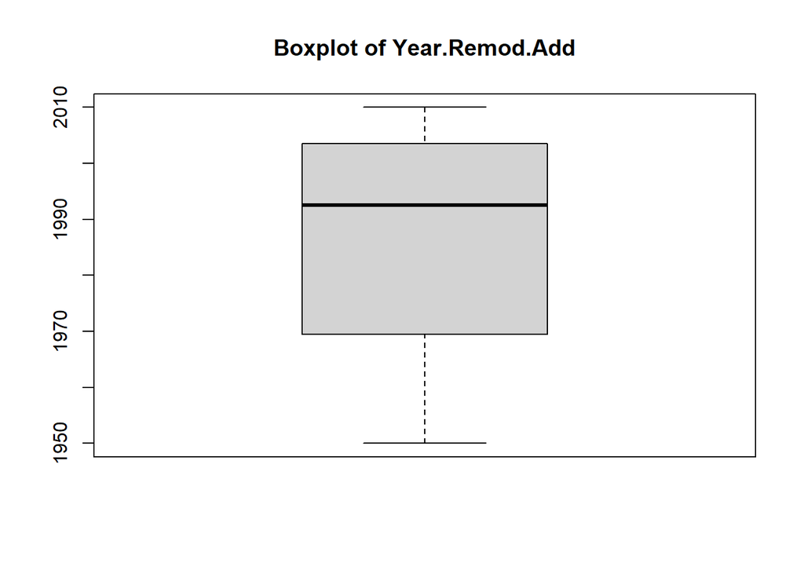

```
## [1] "Removing outliers from Year.Remod.Add : 0 outliers found"
```

```r
for (name in explanatoryVars) {
  if (is.numeric(validation2[[name]])) {
    boxplot(validation2[[name]], main=paste("Boxplot of", name))
    outliers <- boxplot.stats(validation2[[name]])$out
    print(paste("Removing outliers from", name, ":", length(outliers), "outliers found"))
    validation2 <- validation2[!validation2[[name]] %in% outliers, ]
  }
}
```

**modelAlt without outliers in validation set**

```r
predictionsLogAltCleaned_noOutliers<- predict(modelLogAlt_cleaned, newdata = validation2)
predictionsAlt_noOutliers <- exp(predictionsLogAltCleaned_noOutliers)
rmseAltCleaned_noOutliers <- sqrt(mean((validation2$SalePrice - predictionsAlt_noOutliers)^2))
rmseAltCleaned_noOutliers
```

```
## [1] 23836.1
```

**modelFull without outliers in validation set**

```r
validation_full_noOutliers <- validation_full[validation_full$SalePrice %in% validation2$SalePrice, ]
predictionsLogFull_noOutliers<- predict(modelLogFull_cleaned, newdata = validation_full_noOutliers)
predictionsFull_noOutliers <- exp(predictionsLogFull_noOutliers)
rmseFullCleaned_noOutliers <- sqrt(mean((validation_full_noOutliers$SalePrice - predictionsFull_noOutliers)^2))
rmseFullCleaned_noOutliers
```

```
## [1] 24243.45
```

**Lasso without outliers in validation set**

```r
validation_dummies_noOutliers <- validation_dummies[validation_dummies$SalePrice %in% validation2$SalePrice, ]
validation_matrix_noOutliers <- as.matrix(validation_dummies_noOutliers %>% select(-SalePrice, -Log_SalePrice))
predictionsLogLasso_noOutliers<- predict(modelLasso, s = bestLambda, newx = validation_matrix_noOutliers)
predictionsLasso_noOutliers <- exp(predictionsLogLasso_noOutliers)
rmseLasso_noOutliers <- sqrt(mean((validation_dummies_noOutliers$SalePrice - predictionsLasso_noOutliers)^2))
rmseLasso_noOutliers
```

```
## [1] 24154.38
```

# Test prediction of best model

Best model: modelLogAlt_cleaned

## removing outliers from test dataset

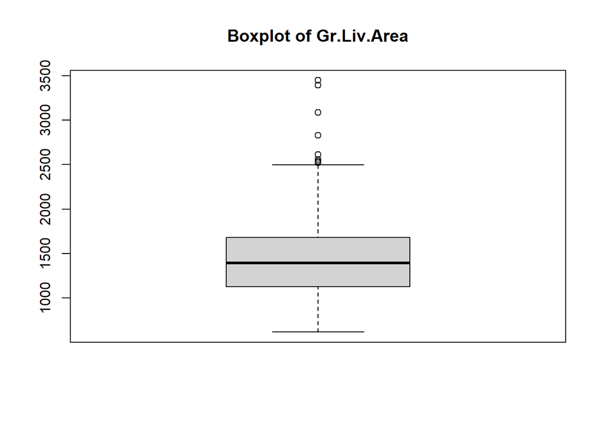

```
## [1] "Removing outliers from Gr.Liv.Area : 8 outliers found"
```

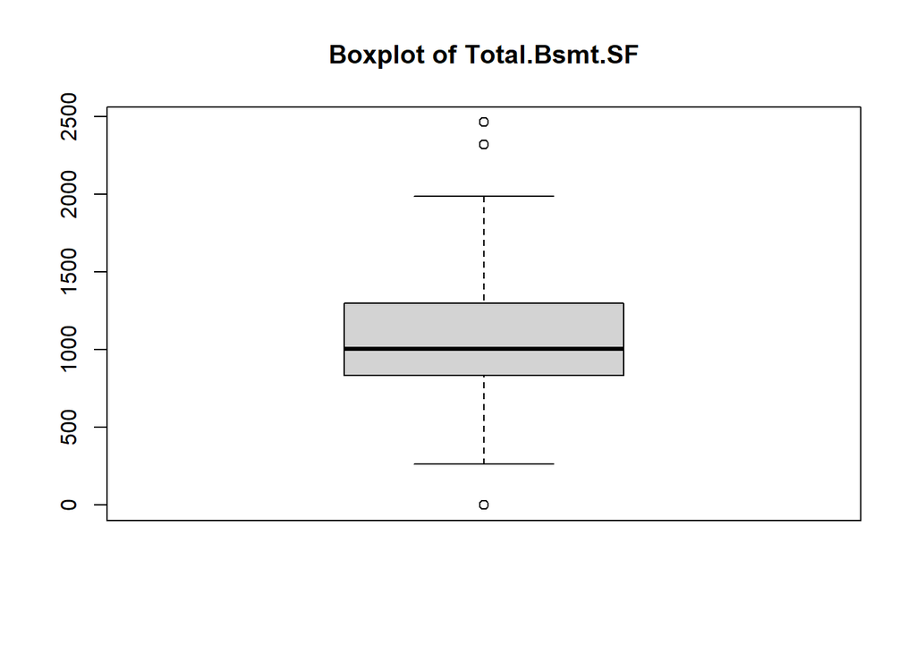

```
## [1] "Removing outliers from Total.Bsmt.SF : 8 outliers found"
```

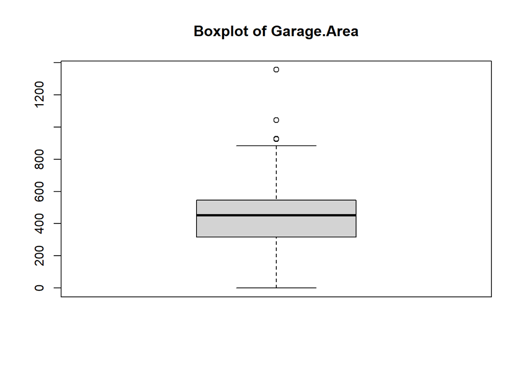

```
## [1] "Removing outliers from Garage.Area : 5 outliers found"
```

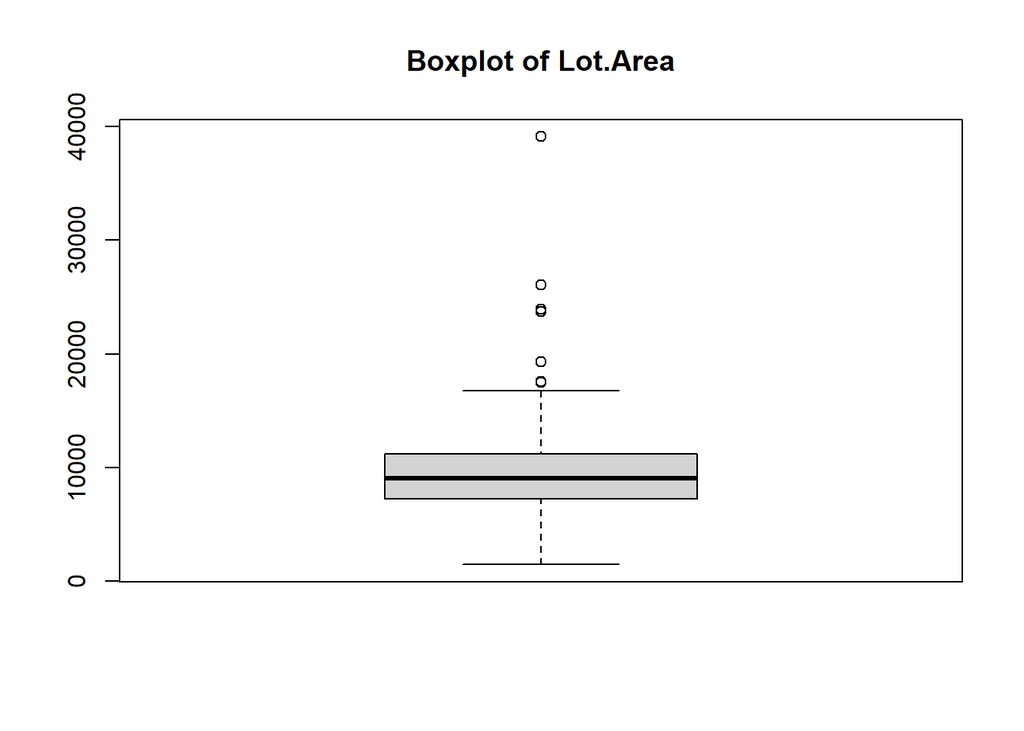

```
## [1] "Removing outliers from Lot.Area : 8 outliers found"
```

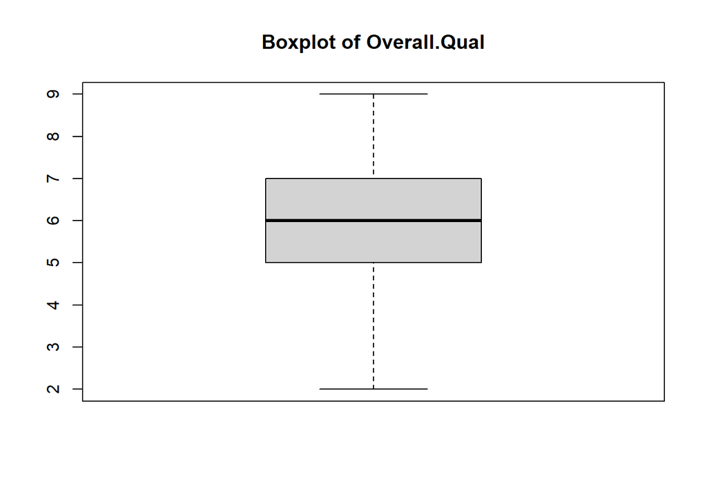

```
## [1] "Removing outliers from Overall.Qual : 0 outliers found"
```

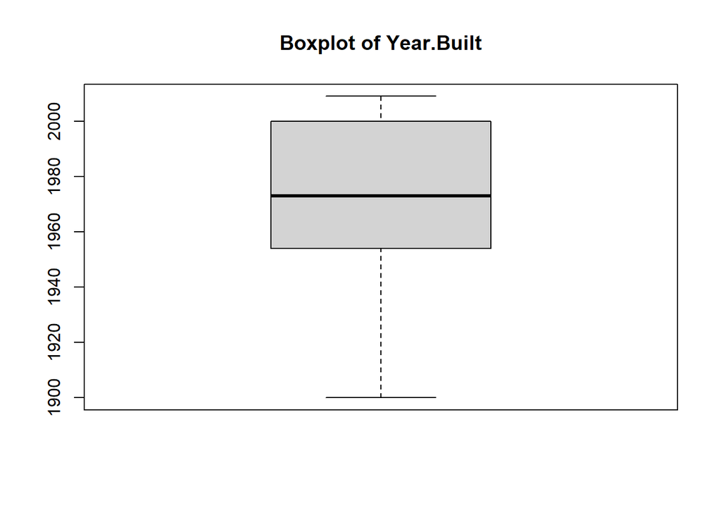

```
## [1] "Removing outliers from Year.Built : 0 outliers found"
```

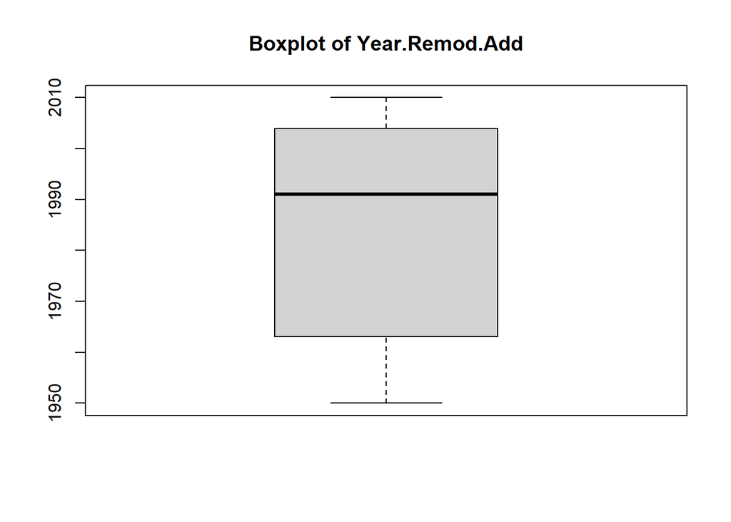

```
## [1] "Removing outliers from Year.Remod.Add : 0 outliers found"
```

```r
for (name in explanatoryVars) {
  if (is.numeric(test[[name]])) {
    boxplot(test[[name]], main=paste("Boxplot of", name))
    outliers <- boxplot.stats(test[[name]])$out
    print(paste("Removing outliers from", name, ":", length(outliers), "outliers found"))
    test <- test[!test[[name]] %in% outliers, ]
  }
}
```

```r
test2 <- test %>%
  mutate(Neighborhood_Price_Range = case_when(
    Neighborhood %in% neigh_summary$Neighborhood[1:7] ~ "Low",
    Neighborhood %in% neigh_summary$Neighborhood[8:14] ~ "Medium",
    Neighborhood %in% neigh_summary$Neighborhood[15:24] ~ "High",
    TRUE ~ "Very_High"
  ))
```

```r
test2 <- test2 %>%
  mutate(House.Style = case_when(
    House.Style %in% house_style_summary$House.Style[1:2] ~ "1.5",
    House.Style %in% house_style_summary$House.Style[4] ~ "1Story",
    House.Style %in% house_style_summary$House.Style[3] ~ "SFoyer",
    House.Style %in% house_style_summary$House.Style[5:6] ~ "Split",
    TRUE ~ "2Story"
  ))
test2$Neighborhood_Price_Range <- factor(test2$Neighborhood_Price_Range,
                                        levels = c( "Medium", "Low", "High", "Very_High"))
test2$House.Style <- factor(test2$House.Style,
                          levels = c("1Story", "2Story", "1.5",  "SFoyer", "Split"))
test2 <- select(test2, -Neighborhood)
test2 <- as_tibble(predict(dummyVars(~ ., sep = ".", data = test2, fullRank = TRUE), newdata = test2))
test2$Log_SalePrice <- log(test2$SalePrice)
```

```r
predictionsLogAltCleaned_test<- predict(modelLogAlt_cleaned, newdata = test2)
predictionsAlt_test <- exp(predictionsLogAltCleaned_test)
rmseAltCleaned_test <- sqrt(mean((test2$SalePrice - predictionsAlt_test)^2))
rmseAltCleaned_test
```

```
## [1] 20190.78
```